# HW1

Junyuan Yi

Wednesday, September 17, 2014

For this homework, I choose GDP dataset from my advanced macroeconomics class for graphics.Since I never use R before, I try to learn from Yang’s tutorial and search on internet to practice scatter graphics with ggplot.

First, let us find some basic information of the dataset.According to the results below, we know that the dataset contains real GDP per capita, which have accounted for inflation and purchase power, of 98 countries in the year 1960 and 2009.

```r
#import dataset
library(xlsx)
gdpdata <- read.xlsx("~/Documents/GDPdata.xlsx",sheetIndex=1)
#basic information
str(gdpdata)
```

```
## 'data.frame':    98 obs. of  4 variables:
##  $ country        : Factor w/ 98 levels "Algeria","Argentina",..: 1 2 3 4 5 6 7 8 9 10 ...
##  $ country.isocode: Factor w/ 98 levels "ARG","AUS","AUT",..: 24 1 2 3 10 5 6 8 9 7 ...
##  $ rgdpch60       : num  3843 7838 10815 8444 7039 ...
##  $ rgdpch2009     : num  6068 11961 41298 37400 22914 ...
```

Start with simple graph, we can plot real GDP percapita of 1960 and 2009 for all countries, as showed below. We notice that most of countries are located in the lower left corner, which means they were poor in 1960 and the situation is not getting better 49 years later. However, a lot of rich countries such as USA, Canada becomes much richer during this period. But the graph is not clear enough to see most of countries or to compare between them.

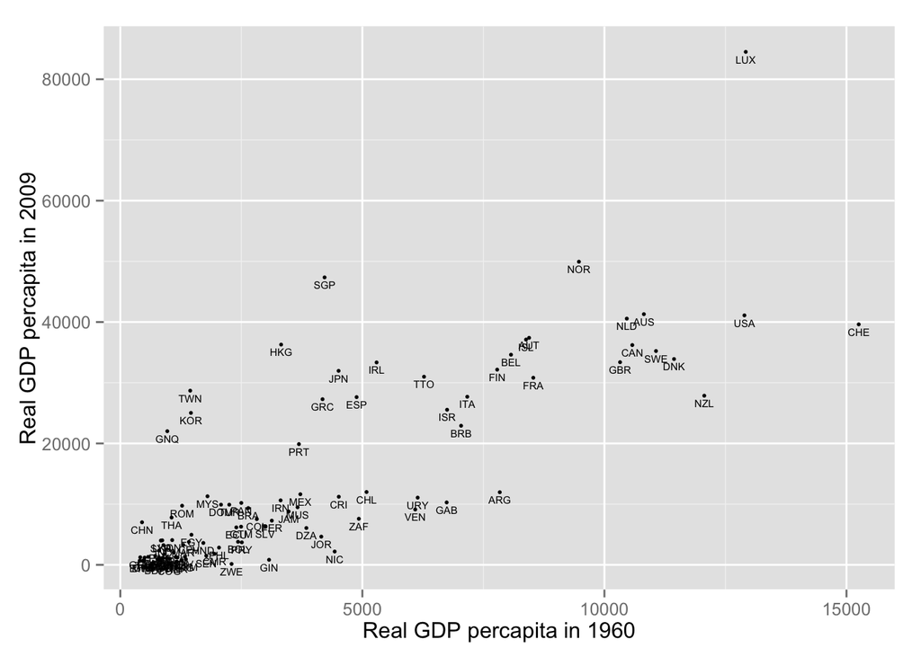

```r
library(ggplot2)
#Plot gdp1960 against gdp2009
ggplot(gdpdata,aes(x=rgdpch60,y=rgdpch2009))+geom_point(size=1)+xlab("Real GDP percapita in 1960")+ylab("Real GDP percapita in 2009")+geom_text(aes(label=country.isocode),size=2,vjust=1.5)
```

We can munipulate our data in two aspets. First, calculating the growth rate of all countries. Second, set the real GDP percapita of USA to standard unit, and calculate the ratio between every other countries to USA. To make the point more scattered, we can further take log of the ratio with base 2(as the difference between first and second graph showed below). Then plot the growth rate against the ratio(relative GDP) of 1960 and 2009

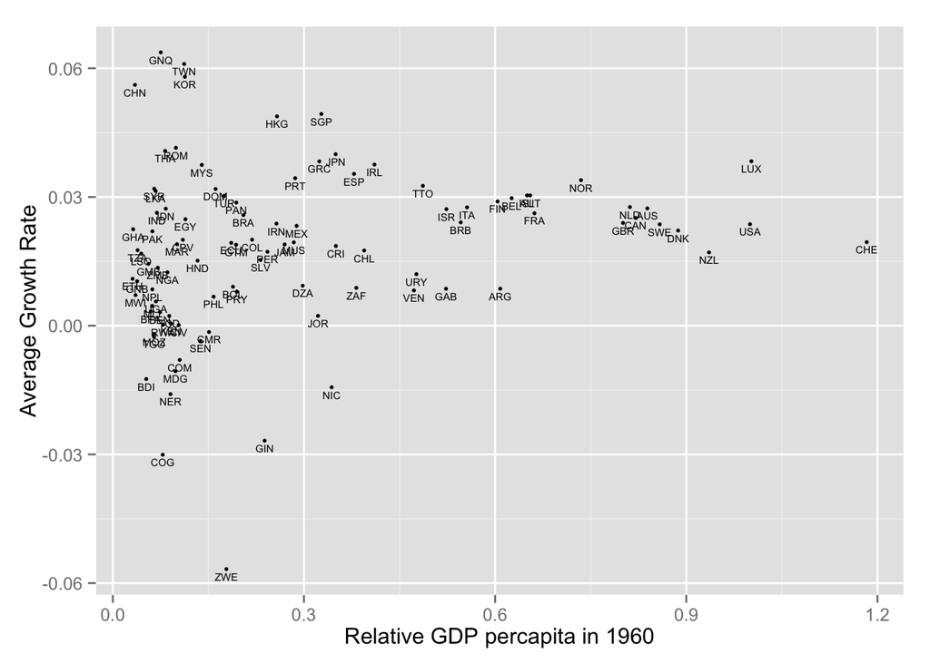

```r
#Calcute the growth rate
gdpdata$growth<-log(gdpdata$rgdpch2009/gdpdata$rgdpch60)/49
#calculate  relative GDP to US
gdpdata$rrgdp60<-gdpdata$rgdpch60/gdpdata[94,3]
gdpdata$rrgdp2009<-gdpdata$rgdpch2009/gdpdata[94,4]
#plot growth rate against relative GDP of 1960 and 2009
ggplot(gdpdata,aes(x=rrgdp60,y=growth))+geom_point(size=1)+xlab("Relative GDP percapita in 1960")+ylab("Average Growth Rate")+geom_text(aes(label=country.isocode),size=2,vjust=1.5)
```

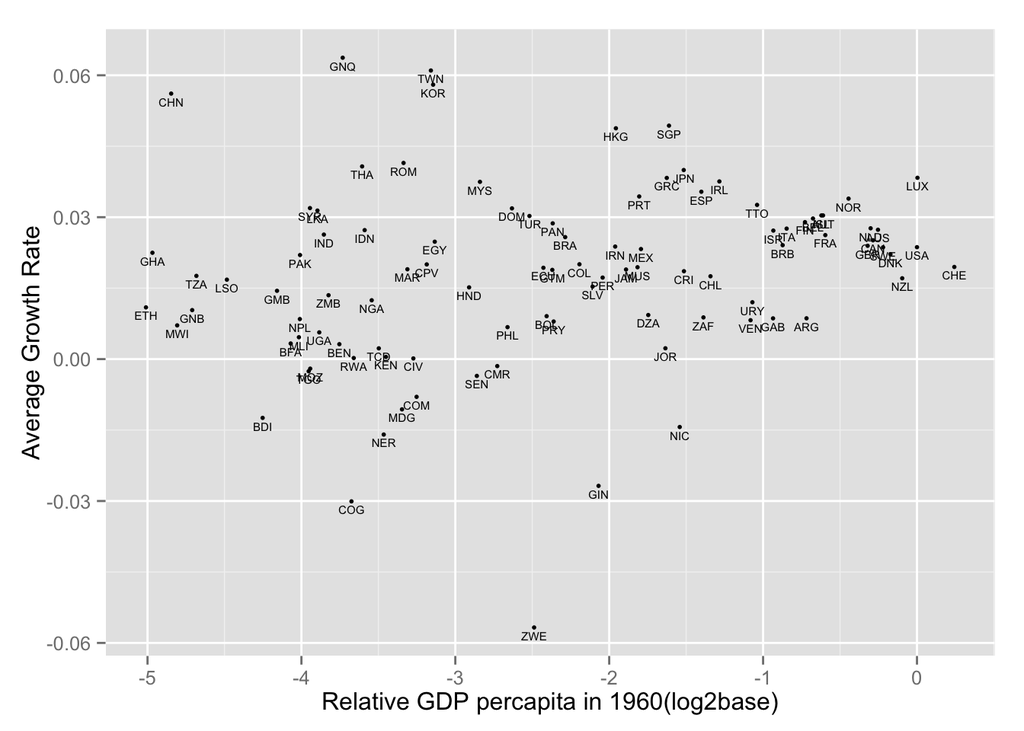

```r
ggplot(gdpdata,aes(x=log2(rrgdp60),y=growth))+geom_point(size=1)+xlab("Relative GDP percapita in 1960(log2base)")+ylab("Average Growth Rate")+geom_text(aes(label=country.isocode),size=2,vjust=1.5)
```

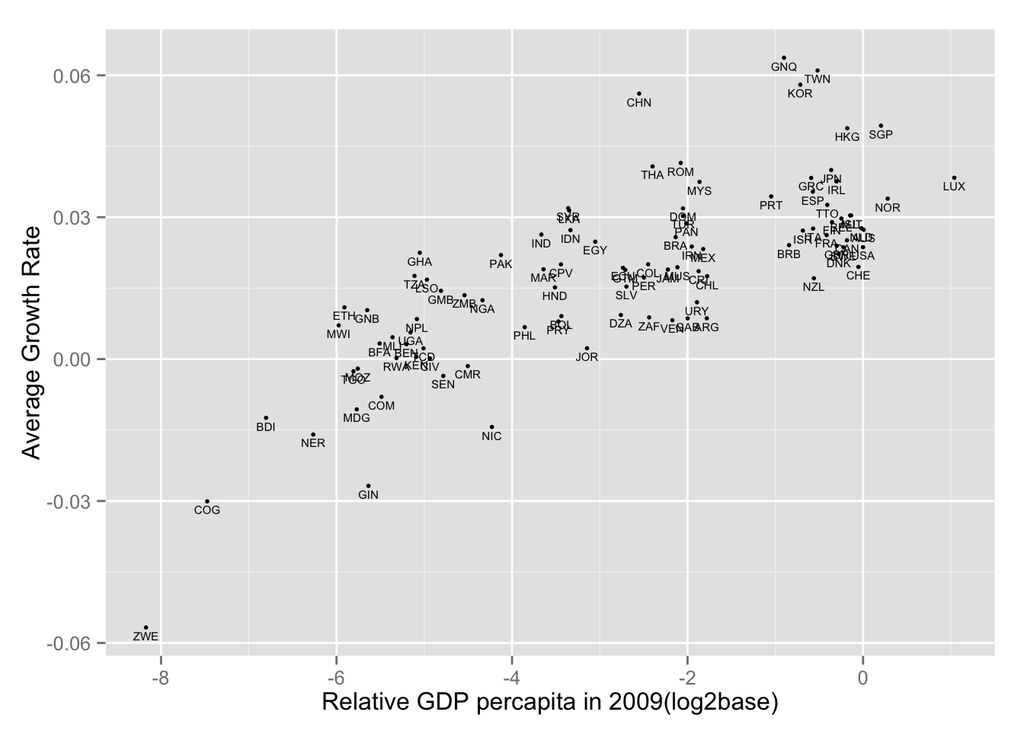

```r
ggplot(gdpdata,aes(x=log2(rrgdp2009),y=growth))+geom_point(size=1)+xlab("Relative GDP percapita in 2009(log2base)")+ylab("Average Growth Rate")+geom_text(aes(label=country.isocode),size=2,vjust=1.5)
```

We could find a lot information for the graphs above, such as the change of individual country, the correlation between current rich countries and their growth rate and so on.

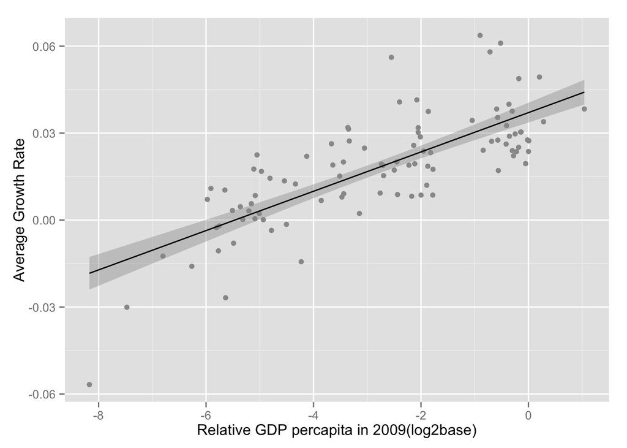

```r
ggplot(gdpdata,aes(x=log2(rrgdp2009),y=growth))+geom_point(size=2,colour="gray60")+xlab("Relative GDP percapita in 2009(log2base)")+ylab("Average Growth Rate")+stat_smooth(method=lm,level=0.90,color="black")
```

Besides, someone may have particular interest of certain countries, so I tried to just keep the label of the countries of my interest to show on the graph.

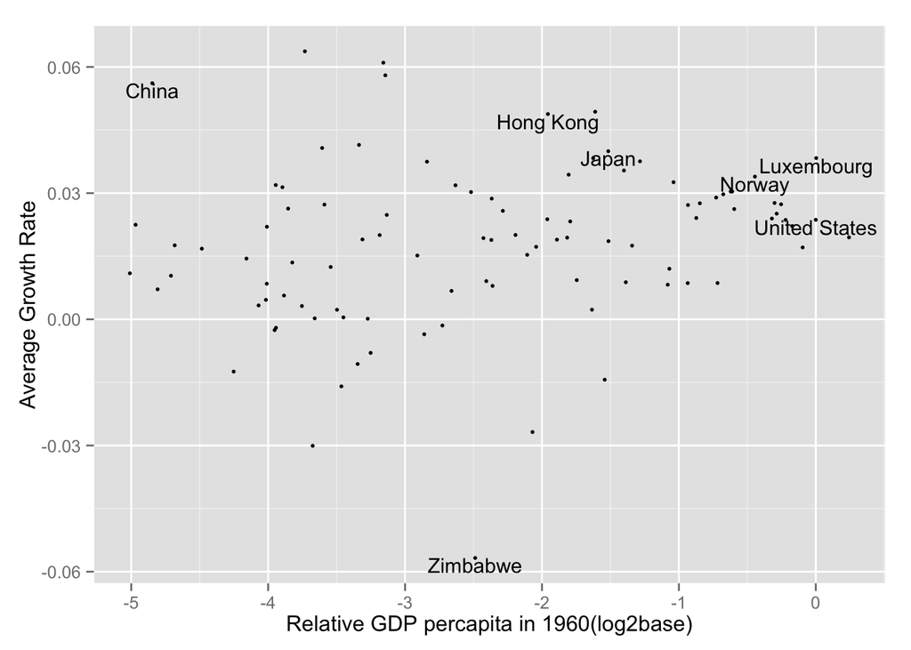

```r
#Only show countries of interest
idx<-gdpdata$country %in% c("China","Japan","United States","Luxembourg","Zimbabwe","Hong Kong","Norway")
gdpdata$countryofint<-gdpdata$country
gdpdata$countryofint[!idx]<-NA
ggplot(gdpdata,aes(x=log2(rrgdp60),y=growth))+geom_point(size=1)+xlab("Relative GDP percapita in 1960(log2base)")+ylab("Average Growth Rate")+geom_text(aes(label=countryofint),size=4,vjust=1)
```

[figure not shown]

```r
ggplot(gdpdata,aes(x=log2(rrgdp2009),y=growth))+geom_point(size=1)+xlab("Relative GDP percapita in 1960(log2base)")+ylab("Average Growth Rate")+geom_text(aes(label=countryofint),size=4,vjust=1)
```